# S2.0: come passa il simulatore dalle cellule ai conteggi nei quadratini di Visium HD, e i pezzi che i dati possono decidere reggono sui vetrini veri?

geo_spatialtrans, report di step (protocollo v2)

Published

November 5, 2026

## In breve: come passa il simulatore dalle cellule ai conteggi nei quadratini di Visium HD, e i pezzi che i dati possono decidere reggono sui vetrini veri?

**A cosa serviva.** Prima di scrivere il codice dello Step 2 (dalle cellule ai conteggi nei quadratini di 2 µm e di 8 µm) serviva il suo documento di progetto. Servivano anche tre cose che solo i vetrini veri potevano decidere: come escono i trascritti dal tessuto ai bordi, come sono fatte le strisce della griglia, quanto variano i conteggi dentro una cellula oltre il caso. Le abbiamo misurate sui cinque vetrini veri, con attese scritte prima del calcolo, poi quattro revisori hanno rifatto i conti con codice proprio.

**Cosa abbiamo trovato.**

1. **Un controllo dei revisori non è passato come scritto, ma nessun numero è meno affidabile per questo.**
   - Chiedeva che il revisore dei bordi ritrovasse le nostre verosimiglianze fino alla sesta cifra decimale: non è possibile, perché il modello lavora in precisione singola. Gli scarti arrivano a 2 centesimi di unità, mentre la somma sulle finestre di una sezione separa le regole a confronto di oltre cento unità. È un errore della mia pre-registrazione, lo stesso visto quando abbiamo misurato la sfocatura ai bordi.
   - Lo stesso revisore ha trovato un difetto vero: in alcune finestre la coda lontana della sfocatura restava spenta perché tutte le partenze dell’adattamento la tenevano spenta. Ho rifatto quelle finestre e tutto ciò che ne dipende: nessun esito cambia, la coda è un po’ più lunga (fino a 41.5 µm nel linfonodo), e il difetto c’era già nel lavoro sui bordi in una finestra del tumore.
   - Tutto il calcolo è stato rifatto una seconda volta da zero con risultati identici, e i file letti non sono cambiati.
2. **I trascritti nati vicino al bordo del tessuto si allargano di più; quelli all’interno quasi non si spostano.**
   - Fra tre spiegazioni vince, in tutte e quattro le sezioni giudicate, la «zona di bordo»: entro 7-25 µm dal bordo i trascritti si allargano di 4.5-6.2 µm, più all’interno meno di 1 µm. Le altre due (due popolazioni di trascritti ovunque, trasporto sul vetro) vanno peggio o si riducono al modello di prima.
   - La stessa regola, misurata sui bordi esterni, descrive i bordi dei buchi interni del tessuto, che non aveva mai visto: 6 combinazioni sezione × distanza su 8 riprodotte, 2 incerte, nessuna sbagliata.
   - La differenza fra nucleo e citoplasma è riprodotta nel tumore, nello stroma e nel cervello; nell’intestino e nel linfonodo l’esito è incerto; nel cuore no (le maschere dei nuclei del cuore non bastano).
3. **Le strisce della griglia non sono solo l’alternanza fra righe pari e dispari: ogni riga e ogni colonna ha una sua efficienza di cattura.**
   - Oltre all’alternanza (fino a 1.75 volte fra colonne dispari e pari nell’intestino), ogni riga e ogni colonna cattura in modo riproducibile circa il 20 % in più o in meno della media. Lo stesso andamento si ritrova sul vetro lontano dal tessuto, quindi è almeno in parte tecnico.
   - Righe e colonne vicine tendono ad alternarsi anche oltre la parità; nel linfonodo l’alternanza cambia da zona a zona.
   - Il revisore ha mostrato che il nostro metodo di stima non fissa le variazioni lente lungo la griglia, e che alcune righe vuote falsavano l’alternanza del linfonodo (da 0.98 a 1.00). Il simulatore usa la parte fine, che è stabile; le variazioni lente restano fuori, come limite.
4. **Dentro il nucleo i conteggi variano più del caso, anche togliendo le strisce.**
   - Con il modello semplice la variabilità osservata è da 3 a 11 volte quella simulata, in tutti e sei i tessuti; da un quarto (cuore) a sette decimi (cervello) dell’eccesso viene dalle strisce per riga e colonna, circa metà negli altri tessuti.
   - Il resto è una variazione della densità su 1-2 µm (quadratini vicini si somigliano, a 4 µm molto meno), e secondo il revisore c’è anche fuori dal nucleo. Non sappiamo se sia biologia (strutture del nucleo) o tecnica.
   - Il simulatore la avrà come strato acceso, che si può spegnere, tarato quando scriveremo la funzione che posiziona e sposta i trascritti.
5. **Il documento di progetto è scritto** (versione 0.2): i sei passi del modello, la tabella dei parametri per tessuto con la fonte di ogni numero, i limiti, il piano in cinque sessioni. Il revisore del documento ha trovato 38 punti, fra cui numeri sbagliati (cellule e trascritti per mm², una frazione scambiata, la regola dei bordi descritta con i valori di quella perdente): tutti corretti o scritti come limiti. Le tre scelte che volevo chiederti (da dove prendere i profili di espressione, quanta profondità, quanta variabilità dentro la cellula) le decidono i dati, come mi hai chiesto: i profili con una gara scritta prima, la profondità tarata sui conteggi veri per quadratino, la variabilità al netto delle strisce.

**Cosa devi decidere.**

1. **Chiudiamo lo step anche se il controllo dei revisori non è passato come scritto sulla sesta cifra decimale? Consiglio di sì.**
   - Il motivo sta nel controllo, non nei dati: la tolleranza era più stretta della precisione con cui il modello calcola. Il difetto vero trovato dal revisore è corretto, e il controllo sulle ottimizzazioni ora passa.
   - Alternativa: rifare la revisione dei bordi con una tolleranza scritta per la precisione singola. Conseguenza: qualche ora di calcolo e di revisione; nessun numero del documento cambierebbe.

**Comunque**: il documento va a Daniele prima del codice. Le cose rinviate (il fondo sul vetro vicino al bordo, il bilancio dei trascritti per area, le variazioni lente delle strisce, l’interno dei nuclei del cuore, la misura di Daniele sui profili dentro la cellula, le code spente nel lavoro sui bordi) sono nel BACKLOG, ciascuna con la sessione che la prende in carico. La prossima sessione costruisce la griglia dei quadratini e la verità geometrica.

Appena decidi questo punto, lo step è chiuso.

# Decisioni e verifiche di Luca

- «Documento + misure + prova del modello (Recommended)»: perimetro dello step (risposta in chat, 2026-11-03).
- «Ok, come proposte (Recommended)»: ok sulle previsioni e sulle soglie (risposta in chat, 2026-11-03).
- «quando puoi stopparti che mi serve il server», poi «riparti pure» (chat, notte fra il 2026-11-03 e il 2026-11-04): calcolo fermato e ripreso dai file salvati.
- «puoi anche aumentare i processi se la temperatura regge, 64 gradi hai ancora 20 gradi di margine» (chat, stessa notte): terzo esecutore, fino a 40 processi.
- «dico sul server. Mi serve libero» (chat, 2026-11-04, 12:04): tutti i processi fermati.
- «riparti, c’è altra roba che gira, prenditi il tuo spazio senza saturalo» (chat, 2026-11-04, 17:07): ripresa con 32 processi.
- «e luca alle 3 domande ti ridpode già che non devi demandare a me quello che puoi decidere tu con i dati» (chat, 2026-11-04): profili, profondità e variabilità a 1-2 µm decisi con i dati (profili scelti dai dati, profondità tarata, variabilità al netto delle strisce (DEC-040)).
- «chiudi» (chat, 2026-11-05): risposta all’unica decisione del riassunto; lo step si chiude con il ricalcolo indipendente dei bordi fallito come scritto sulla tolleranza di un milionesimo (chiusura con G-5 fallito come scritto (DEC-041)).

# Dubbi rinviati

| cosa | perché | cosa serve per chiuderlo | step destinatario | voce di BACKLOG |
| --- | --- | --- | --- | --- |
| misura di Daniele sui profili dentro la cellula (correlazione fra i profili per gene dei bin della stessa cellula, contro cellule dello stesso tipo) | S2.0 misura i totali per bin, non la composizione | profili scelti e cellule vere di R6 | S2.2 | BL-204 |
| bilancio dei trascritti per area e fattore di profondità (stima provvisoria: 67-82 % degli UMI veri, un terzo nel cuore) | serve il modello delle cellule | taratura del fattore per tessuto sugli UMI per bin di R4, verifica su una sezione | S2.2, S2.5 | BL-205 |
| fondo sul vetro vicino al bordo più alto di quello del vetro lontano (intestino, tumore, cervello) | forse una coda non modellata | fondo per distanza dal bordo contro lo spostamento simulato | S2.3 | BL-206 |
| variabilità a 1-2 µm: nullo simulato per corona e spazio acellulare, origine, maschera allineata nell’intestino (v sottostimato di circa il 20 %), densità acellulare sul vetro della ROI nel prototipo,… | revisione G-5 (nucleo) | taratura del campo sul modello completo con maschere allineate e nullo simulato per tutti gli strati | S2.3 | BL-207 |
| strisce: variazioni lente lungo righe e colonne non identificate; passo 1 per il generatore estrapolato oltre −0.3 | stimatore alternato con campo lisciato | stimatore vincolato (per esempio con il vetro) e calibrazione estesa | S2.4 | BL-208 |
| costo della sovra-generazione per l’assottigliamento, max(c)/media(c) per tessera | prestazioni | misura su un’area intera | S2.4 | BL-209 |
| cuore: il modello non descrive l’interno dei nuclei; r e v con riserva | maschere dei nuclei del cuore | maschere migliori o modello diverso | da assegnare (con BL-199) | BL-210 |
| soluzioni con la coda spenta anche nel lavoro sui bordi (R5): due finestre del tumore migliorano di 20 e 167 unità | partenze ereditate | riadattare R5 con le partenze di PH-6 e aggiornare i suoi riferimenti della coda | da assegnare | BL-211 |

# Cancelli

Cancelli

| id | controllo | esito |
| --- | --- | --- |
| G-1 | batteria di test su sezioni sintetiche e mutanti (`tools/S2.0_test.py`) | S2.0_test: 44/44 PASS (1343 s) |
| G-2 | md5 di ogni file letto, prima e dopo (`tools/S2.0_md5.sh`) | G-2 PASS: 1623/1623 file letti con md5 identici prima e dopo (results/S2.0/S2.0_md5_before.txt, _after.txt) |
| G-3 | il documento di design contro i dati e le fonti (`tools/S2.0_design_check.py`) | S2.0_design_check: 37/37 PASS |
| G-4 | riproducibilità: seconda esecuzione completa (`tools/S2.0_chain.sh`, `tools/S2.0_repro.sh`) | G-4 PASS: 10/10 tabelle con md5 identici, 514 file per unità identici a meno dei tempi (run1 contro run2) |
| G-5 | revisione avversariale (quattro revisori indipendenti) | vedi «Revisione avversariale» |

# Previsioni e controprova

Pre-registrazione: `docs/steps/S2.0.md` (commit `afef06b`, correzioni AM-1…AM-5 prima del calcolo); ok di Luca sulle previsioni e sulle soglie il 2026-11-03.

Previsioni pre-registrate, come calcolate (stima con intervallo bootstrap al 95 %, B = 2000, seme 20261103)

| id | unità | quantità | stima | lo | hi | intervallo | esito | note |
| --- | --- | --- | --- | --- | --- | --- | --- | --- |
| P-1 | intestino di topo | SD riproducibile dei fattori non periodici (rows) | 0.205 | 0.197 | 0.213 | [0, 0.05] | smentita | parita’ 1.417; r fra meta’ 0.906; passo 1 -0.187 |
| P-1 | intestino di topo | SD riproducibile dei fattori non periodici (cols) | 0.188 | 0.182 | 0.193 | [0, 0.05] | smentita | parita’ 1.750; r fra meta’ 0.859; passo 1 -0.248 |
| P-2 | intestino di topo | SD riproducibile fra tessere del log dispari/pari (cols) | 0.014 | 0.010 | 0.017 | [0, 0.05] | confermata | mediana 1.745 (p10 1.703, p90 1.795); tessere 266 |
| P-2 | intestino di topo | SD riproducibile fra tessere del log dispari/pari (rows) | 0.004 | 0.000 | 0.019 | [0, 0.05] | confermata | mediana 1.403 (p10 1.342, p90 1.461); tessere 266 |
| P-1 | tumore del colon (e stroma) | SD riproducibile dei fattori non periodici (rows) | 0.225 | 0.217 | 0.232 | [0, 0.05] | smentita | parita’ 1.578; r fra meta’ 0.919; passo 1 -0.288 |
| P-1 | tumore del colon (e stroma) | SD riproducibile dei fattori non periodici (cols) | 0.196 | 0.192 | 0.201 | [0, 0.05] | smentita | parita’ 1.724; r fra meta’ 0.904; passo 1 -0.179 |
| P-2 | tumore del colon (e stroma) | SD riproducibile fra tessere del log dispari/pari (cols) | 0.010 | 0.005 | 0.014 | [0, 0.05] | confermata | mediana 1.709 (p10 1.656, p90 1.757); tessere 369 |
| P-2 | tumore del colon (e stroma) | SD riproducibile fra tessere del log dispari/pari (rows) | 0.002 | 0.000 | 0.013 | [0, 0.05] | confermata | mediana 1.599 (p10 1.542, p90 1.664); tessere 369 |
| P-1 | linfonodo | SD riproducibile dei fattori non periodici (rows) | 0.225 | 0.214 | 0.239 | [0, 0.05] | smentita | parita’ 0.980; r fra meta’ 0.732; passo 1 -0.207 |
| P-1 | linfonodo | SD riproducibile dei fattori non periodici (cols) | 0.282 | 0.253 | 0.314 | [0, 0.05] | smentita | parita’ 1.125; r fra meta’ 0.393; passo 1 -0.119 |
| P-2 | linfonodo | SD riproducibile fra tessere del log dispari/pari (cols) | 0.047 | 0.029 | 0.061 | [0, 0.05] | indeterminata | mediana 1.110 (p10 1.010, p90 1.176); tessere 239 |
| P-2 | linfonodo | SD riproducibile fra tessere del log dispari/pari (rows) | 0.089 | 0.066 | 0.110 | [0, 0.05] | smentita | mediana 0.999 (p10 0.874, p90 1.074); tessere 239 |
| P-1 | cervello di topo | SD riproducibile dei fattori non periodici (rows) | 0.248 | 0.241 | 0.255 | [0, 0.05] | smentita | parita’ 1.178; r fra meta’ 0.932; passo 1 -0.258 |
| P-1 | cervello di topo | SD riproducibile dei fattori non periodici (cols) | 0.184 | 0.178 | 0.191 | [0, 0.05] | smentita | parita’ 1.231; r fra meta’ 0.880; passo 1 -0.265 |
| P-2 | cervello di topo | SD riproducibile fra tessere del log dispari/pari (cols) | 0.015 | 0.011 | 0.019 | [0, 0.05] | confermata | mediana 1.230 (p10 1.190, p90 1.271); tessere 283 |
| P-2 | cervello di topo | SD riproducibile fra tessere del log dispari/pari (rows) | 0.000 | 0.000 | 0.000 | [0, 0.05] | confermata | mediana 1.180 (p10 1.141, p90 1.247); tessere 283 |
| P-1 | cuore | SD riproducibile dei fattori non periodici (rows) | 0.195 | 0.180 | 0.218 | [0, 0.05] | smentita | parita’ 0.947; r fra meta’ 0.957; passo 1 -0.071 |
| P-1 | cuore | SD riproducibile dei fattori non periodici (cols) | 0.190 | 0.185 | 0.194 | [0, 0.05] | smentita | parita’ 0.967; r fra meta’ 0.938; passo 1 -0.215 |
| P-2 | cuore | SD riproducibile fra tessere del log dispari/pari (cols) | 0.012 | 0.007 | 0.015 | [0, 0.05] | confermata | mediana 0.965 (p10 0.930, p90 0.999); tessere 468 |
| P-2 | cuore | SD riproducibile fra tessere del log dispari/pari (rows) | 0.020 | 0.014 | 0.025 | [0, 0.05] | confermata | mediana 0.941 (p10 0.906, p90 1.009); tessere 468 |
| P-3 | tumore del colon | previsto/osservato senza i bin entro 2 µm dal bordo del nucleo, regola C1 | — | — | — | [0.909, 1.1] | non calcolabile come scritto | ROI non invertibili 1/5; sulle ROI riuscite 0.867 [0.841, 0.886] |
| P-3 | cervello di topo | previsto/osservato senza i bin entro 2 µm dal bordo del nucleo, regola C1 | 1.010 | 0.994 | 1.027 | [0.909, 1.1] | confermata | ROI non invertibili 0/5; sulle ROI riuscite 1.010 [0.994, 1.027] |
| P-4 | intestino di topo | indice di dispersione dentro il nucleo, osservato/simulato | 3.898 | 3.266 | 4.516 | [0.909, 1.1] | smentita | v 0.1023 [0.0958, 0.1096]; psi oss 5.760, sim 1.507; r da inverted |
| P-4 | tumore del colon | indice di dispersione dentro il nucleo, osservato/simulato | 7.412 | 7.167 | 7.697 | [0.909, 1.1] | smentita | v 0.1440 [0.1334, 0.1547]; psi oss 7.857, sim 1.060; r da inverted |
| P-4 | stroma del tumore | indice di dispersione dentro il nucleo, osservato/simulato | 5.522 | 4.849 | 5.987 | [0.909, 1.1] | smentita | v 0.1698 [0.1609, 0.1792]; psi oss 5.668, sim 1.026; r da inverted |
| P-4 | linfonodo | indice di dispersione dentro il nucleo, osservato/simulato | 2.927 | 2.630 | 3.115 | [0.909, 1.1] | smentita | v 0.1592 [0.1543, 0.1643]; psi oss 3.204, sim 1.093; r da inverted |
| P-4 | cervello di topo | indice di dispersione dentro il nucleo, osservato/simulato | 10.890 | 10.260 | 11.367 | [0.909, 1.1] | smentita | v 0.1145 [0.1122, 0.1167]; psi oss 11.374, sim 1.045; r da inverted |
| P-4 | cuore | indice di dispersione dentro il nucleo, osservato/simulato | 3.043 | 2.645 | 3.547 | [0.909, 1.1] | smentita | v 0.2010 [0.1754, 0.2310]; psi oss 3.135, sim 1.031; r da inverted |
| CP-1 | A1, A23, A4, A6 | lumi interni, osservati/previsti con C2, fasce 2-4 e 4-8 µm | 0.000 | — | — | 0 celle smentite su 8 | superata | celle smentite 0 |

Le stesse previsioni con le soluzioni dei bordi corrette (post hoc PH-6): esiti identici in 29/29

| id | unità | prima | esito_prima | dopo | lo | hi | esito_dopo |
| --- | --- | --- | --- | --- | --- | --- | --- |
| CP-1 | A1, A23, A4, A6 | 0.000 | superata | 0.000 | — | — | superata |
| P-1 | A1 | 0.188 | smentita | 0.188 | 0.182 | 0.193 | smentita |
| P-1 | A1 | 0.205 | smentita | 0.205 | 0.197 | 0.213 | smentita |
| P-1 | A23 | 0.196 | smentita | 0.196 | 0.192 | 0.201 | smentita |
| P-1 | A23 | 0.225 | smentita | 0.225 | 0.217 | 0.232 | smentita |
| P-1 | A4 | 0.282 | smentita | 0.282 | 0.253 | 0.314 | smentita |
| P-1 | A4 | 0.225 | smentita | 0.225 | 0.214 | 0.239 | smentita |
| P-1 | A5 | 0.184 | smentita | 0.184 | 0.178 | 0.191 | smentita |
| P-1 | A5 | 0.248 | smentita | 0.248 | 0.241 | 0.255 | smentita |
| P-1 | A6 | 0.190 | smentita | 0.190 | 0.185 | 0.194 | smentita |
| P-1 | A6 | 0.195 | smentita | 0.195 | 0.180 | 0.218 | smentita |
| P-2 | A1 | 0.014 | confermata | 0.014 | 0.010 | 0.017 | confermata |
| P-2 | A1 | 0.004 | confermata | 0.004 | 0.000 | 0.019 | confermata |
| P-2 | A23 | 0.010 | confermata | 0.010 | 0.005 | 0.014 | confermata |
| P-2 | A23 | 0.002 | confermata | 0.002 | 0.000 | 0.013 | confermata |
| P-2 | A4 | 0.047 | indeterminata | 0.047 | 0.029 | 0.061 | indeterminata |
| P-2 | A4 | 0.089 | smentita | 0.089 | 0.066 | 0.110 | smentita |
| P-2 | A5 | 0.015 | confermata | 0.015 | 0.011 | 0.019 | confermata |
| P-2 | A5 | 0.000 | confermata | 0.000 | 0.000 | 0.000 | confermata |
| P-2 | A6 | 0.012 | confermata | 0.012 | 0.007 | 0.015 | confermata |
| P-2 | A6 | 0.020 | confermata | 0.020 | 0.014 | 0.025 | confermata |
| P-3 | A2 | — | non calcolabile come scritto | — | — | — | non calcolabile come scritto |
| P-3 | A5 | 1.010 | confermata | 1.010 | 0.994 | 1.027 | confermata |
| P-4 | A1 | 3.898 | smentita | 3.896 | 3.263 | 4.514 | smentita |
| P-4 | A2 | 7.412 | smentita | 7.413 | 7.167 | 7.698 | smentita |
| P-4 | A3 | 5.522 | smentita | 5.522 | 4.849 | 5.987 | smentita |
| P-4 | A4 | 2.927 | smentita | 2.927 | 2.630 | 3.114 | smentita |
| P-4 | A5 | 10.890 | smentita | 10.890 | 10.260 | 11.367 | smentita |
| P-4 | A6 | 3.043 | smentita | 3.043 | 2.645 | 3.547 | smentita |

# Strisce della griglia (M1, P-1, P-2, regola R-B)

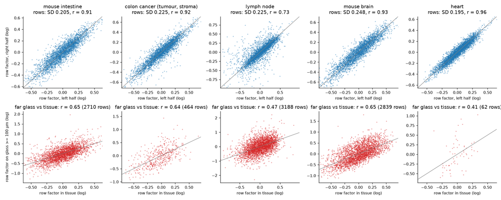

*Cosa guardare*: in alto, il fattore di ogni riga stimato sulla metà sinistra contro quello stimato sulla metà destra: i punti stanno sulla diagonale, quindi la parte non periodica è riproducibile. In basso, lo stesso fattore sul vetro lontano dal tessuto: è correlato (analisi post hoc PH-1).

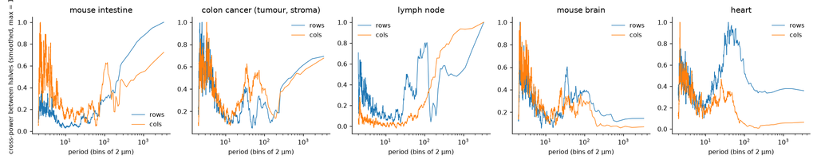

Post hoc PH-5: parte fine dei fattori (scarto dalla media mobile su 21), righe e colonne a zero UMI tolte, a 10 e 20 iterazioni

| key | n_iter | axis | zero_rows_removed | zero_cols_removed | odd_over_even | sd_repro_all | sd_repro_hp | corr_halves_hp | lag1_repro_hp | n_hp |
| --- | --- | --- | --- | --- | --- | --- | --- | --- | --- | --- |
| A1 | 10 | rows | 0 | 0 | 1.4171 | 0.2046 | 0.1933 | 0.9547 | -0.3307 | 2845 |
| A1 | 10 | cols | 0 | 0 | 1.7501 | 0.1878 | 0.1847 | 0.9537 | -0.3058 | 2925 |
| A1 | 20 | rows | 0 | 0 | 1.4167 | 0.2264 | 0.1934 | 0.9541 | -0.3293 | 2845 |
| A1 | 20 | cols | 0 | 0 | 1.7500 | 0.1944 | 0.1848 | 0.9529 | -0.3049 | 2925 |
| A23 | 10 | rows | 0 | 0 | 1.5777 | 0.2246 | 0.2210 | 0.9655 | -0.3369 | 2974 |
| A23 | 10 | cols | 0 | 0 | 1.7242 | 0.1964 | 0.1909 | 0.9519 | -0.2536 | 3350 |
| A23 | 20 | rows | 0 | 0 | 1.5779 | 0.2294 | 0.2210 | 0.9651 | -0.3364 | 2974 |
| A23 | 20 | cols | 0 | 0 | 1.7242 | 0.2025 | 0.1909 | 0.9514 | -0.2528 | 3350 |
| A4 | 10 | rows | 7 | 1 | 0.9964 | 0.2252 | 0.2115 | 0.8553 | -0.3936 | 3190 |
| A4 | 10 | cols | 7 | 1 | 1.1054 | 0.2816 | 0.2507 | 0.3850 | -0.4649 | 2851 |
| A4 | 20 | rows | 7 | 1 | 0.9963 | 0.2423 | 0.2117 | 0.8554 | -0.3908 | 3190 |
| A4 | 20 | cols | 7 | 1 | 1.1055 | 0.3302 | 0.2507 | 0.3844 | -0.4655 | 2851 |
| A5 | 10 | rows | 1 | 0 | 1.2006 | 0.2482 | 0.2420 | 0.9684 | -0.3343 | 2839 |
| A5 | 10 | cols | 1 | 0 | 1.2314 | 0.1837 | 0.1804 | 0.9382 | -0.3238 | 2847 |
| A5 | 20 | rows | 1 | 0 | 1.2005 | 0.2526 | 0.2421 | 0.9676 | -0.3336 | 2839 |
| A5 | 20 | cols | 1 | 0 | 1.2318 | 0.1874 | 0.1806 | 0.9378 | -0.3215 | 2847 |
| A6 | 10 | rows | 0 | 0 | 0.9469 | 0.1945 | 0.1828 | 0.9716 | -0.2175 | 3350 |
| A6 | 10 | cols | 0 | 0 | 0.9670 | 0.1897 | 0.1878 | 0.9592 | -0.2500 | 3350 |
| A6 | 20 | rows | 0 | 0 | 0.9468 | 0.2003 | 0.1829 | 0.9714 | -0.2154 | 3350 |
| A6 | 20 | cols | 0 | 0 | 0.9670 | 0.1909 | 0.1878 | 0.9589 | -0.2495 | 3350 |

Post hoc PH-5: calibrazione su sezioni sintetiche con fattori noti (media di 4 semi e due assi)

| amp | rho_true | sd_true_hp_sample | sd_repro_hp | lag1_true_hp_sample | lag1_repro_hp |
| --- | --- | --- | --- | --- | --- |
| 0.2 | -0.3 | 0.201 | 0.202 | -0.313 | -0.324 |
| 0.4 | -0.3 | 0.199 | 0.200 | -0.325 | -0.330 |
| 0.2 | -0.2 | 0.201 | 0.201 | -0.236 | -0.238 |
| 0.4 | -0.2 | 0.198 | 0.196 | -0.247 | -0.248 |
| 0.2 | 0.0 | 0.197 | 0.197 | -0.055 | -0.050 |
| 0.4 | 0.0 | 0.201 | 0.201 | -0.076 | -0.083 |

Post hoc PH-4: passo 1 e deviazione standard restituiti dallo stimatore su sezioni sintetiche con fattori noti (media di 4 semi e due assi)

| amp | rho_true | lag1_true_sample | lag1_repro | sd_true_np | sd_repro |
| --- | --- | --- | --- | --- | --- |
| 0.2 | -0.2 | -0.218 | -0.240 | 0.200 | 0.198 |
| 0.4 | -0.2 | -0.218 | -0.239 | 0.200 | 0.199 |
| 0.2 | 0.0 | -0.017 | -0.044 | 0.199 | 0.197 |
| 0.4 | 0.0 | -0.017 | -0.053 | 0.199 | 0.196 |

# Regola d’uscita dei trascritti dal tessuto (M2, regola R-A)

Parametri per sezione dopo PH-6 (mediana delle finestre, intervallo bootstrap) e differenza di AIC per finestra contro il nucleo di R5; prima di PH-6: results/S2.0/S2.0_edges_sections.csv

| sezione | regola | parametro | mediana | lo | hi | finestre |
| --- | --- | --- | --- | --- | --- | --- |
| intestino di topo | C0 | sigma | 5.160 | 4.876 | 5.529 | 130 |
| intestino di topo | C0 | w | 0.099 | 0.088 | 0.108 | 130 |
| intestino di topo | C0 | ell | 27.679 | 23.728 | 31.114 | 130 |
| intestino di topo | C1 | q | 1.000 | 1.000 | 1.000 | 130 |
| intestino di topo | C1 | p | 0.899 | 0.883 | 0.910 | 130 |
| intestino di topo | C1 | sigma_m | 5.229 | 4.899 | 5.554 | 130 |
| intestino di topo | C1 | w | 0.099 | 0.086 | 0.108 | 130 |
| intestino di topo | C1 | ell | 27.717 | 23.727 | 31.120 | 130 |
| intestino di topo | C2 | sigma_e | 6.225 | 6.030 | 6.418 | 130 |
| intestino di topo | C2 | D | 24.747 | 18.857 | 35.201 | 130 |
| intestino di topo | C2 | w | 0.087 | 0.076 | 0.096 | 130 |
| intestino di topo | C2 | ell | 32.852 | 28.801 | 36.400 | 130 |
| intestino di topo | C3 | sigma_g | 0.050 | 0.050 | 0.050 | 130 |
| intestino di topo | C3 | w | 0.860 | 0.775 | 0.904 | 130 |
| intestino di topo | C3 | ell | 5.000 | 5.000 | 5.000 | 130 |
| intestino di topo | C1 | dAIC_vs_C0_per_window | 2.000 | 1.999 | 2.000 | 130 |
| intestino di topo | C1 | sum_AIC | -26693874.336 | — | — | 130 |
| intestino di topo | C2 | dAIC_vs_C0_per_window | -115.774 | -187.494 | -71.054 | 130 |
| intestino di topo | C2 | sum_AIC | -26789318.721 | — | — | 130 |
| intestino di topo | C3 | dAIC_vs_C0_per_window | 839.175 | 566.274 | 945.043 | 130 |
| intestino di topo | C3 | sum_AIC | -26556729.131 | — | — | 130 |
| intestino di topo | C0 | sum_AIC | -26693973.438 | — | — | 130 |
| tumore del colon (e stroma) | C0 | sigma | 3.461 | 3.352 | 3.975 | 59 |
| tumore del colon (e stroma) | C0 | w | 0.060 | 0.051 | 0.070 | 59 |
| tumore del colon (e stroma) | C0 | ell | 15.535 | 11.676 | 20.319 | 59 |
| tumore del colon (e stroma) | C1 | q | 1.000 | 1.000 | 1.000 | 59 |
| tumore del colon (e stroma) | C1 | p | 0.922 | 0.895 | 0.936 | 59 |
| tumore del colon (e stroma) | C1 | sigma_m | 3.512 | 3.430 | 4.018 | 59 |
| tumore del colon (e stroma) | C1 | w | 0.058 | 0.050 | 0.067 | 59 |
| tumore del colon (e stroma) | C1 | ell | 15.536 | 10.890 | 23.549 | 59 |

[output cut: 80 more lines]

R-A: somma degli AIC per sezione; vincente: C2

| sezione | C1 | C2 | C3 | vincente |
| --- | --- | --- | --- | --- |
| intestino di topo | -26693874 | -26789319 | -26556729.1 | C2 |
| tumore del colon (e stroma) | -33925269 | -33983015 | -33763640.9 | C2 |
| linfonodo | 670269 | 670040 | 672540.7 | C2 |
| cervello di topo | -7284364 | -7288530 | -7265261.8 | C2 |

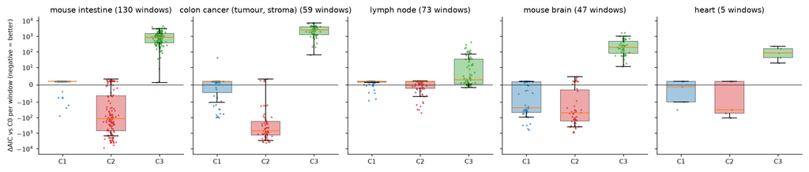

*Cosa guardare*: la zona di bordo (rosso) sta sotto lo zero (meglio del nucleo di R5) in quasi tutte le finestre di intestino, tumore e cervello; nel linfonodo le regole non si distinguono; il trasporto sul vetro (verde) è sempre peggiore.

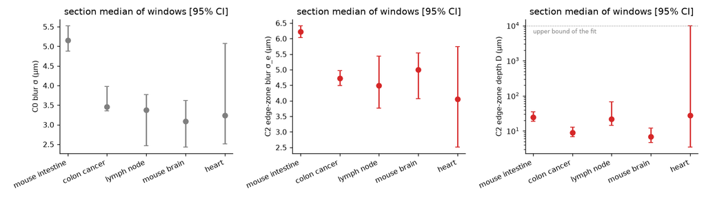

Controllo interno: contrasto fra nucleo e citoplasma senza i bin entro 2 µm dal bordo del nucleo (pre-registrato in tumore e cervello, descrittivo altrove)

| tessuto | regola | previsto/osservato | lo | hi | esito | ROI non invertibili | solo ROI riuscite | r |
| --- | --- | --- | --- | --- | --- | --- | --- | --- |
| intestino di topo | C0 | — | — | — | non calcolabile come scritto | 3 | 0.964 | 0.071 |
| intestino di topo | C0_r5u | — | — | — | non calcolabile come scritto | 4 | 0.957 | 0.111 |
| intestino di topo | C1 | — | — | — | non calcolabile come scritto | 4 | 0.956 | 0.071 |
| intestino di topo | C2 | 0.903 | 0.833 | 0.973 | indeterminata | 0 | 0.903 | 0.746 |
| intestino di topo | C3 | — | — | — | non calcolabile come scritto | 2 | 0.952 | 0.507 |
| tumore del colon | C0 | — | — | — | non calcolabile come scritto | 1 | 0.869 | 0.155 |
| tumore del colon | C0_r5u | — | — | — | non calcolabile come scritto | 1 | 0.870 | 0.154 |
| tumore del colon | C1 | — | — | — | non calcolabile come scritto | 2 | 0.880 | 0.143 |
| tumore del colon | C2 | 0.999 | 0.992 | 1.006 | confermata | 0 | 0.999 | 0.755 |
| tumore del colon | C3 | 0.989 | 0.983 | 0.996 | confermata | 0 | 0.989 | 0.613 |
| stroma del tumore | C0 | — | — | — | non calcolabile come scritto | 1 | 0.905 | 0.327 |
| stroma del tumore | C0_r5u | — | — | — | non calcolabile come scritto | 1 | 0.902 | 0.322 |
| stroma del tumore | C1 | — | — | — | non calcolabile come scritto | 1 | 0.904 | 0.311 |
| stroma del tumore | C2 | 0.972 | 0.956 | 0.990 | confermata | 0 | 0.972 | 0.821 |
| stroma del tumore | C3 | 0.966 | 0.951 | 0.983 | confermata | 0 | 0.966 | 0.701 |
| linfonodo | C0 | — | — | — | non calcolabile come scritto | 5 | — | — |
| linfonodo | C0_r5u | — | — | — | non calcolabile come scritto | 5 | — | — |
| linfonodo | C1 | — | — | — | non calcolabile come scritto | 5 | — | — |
| linfonodo | C2 | 0.884 | 0.836 | 0.940 | indeterminata | 0 | 0.884 | 0.546 |
| linfonodo | C3 | 0.861 | 0.815 | 0.913 | indeterminata | 0 | 0.861 | 0.241 |
| cervello di topo | C0 | 1.026 | 1.008 | 1.046 | confermata | 0 | 1.026 | 1.740 |
| cervello di topo | C0_r5u | 1.026 | 1.007 | 1.048 | confermata | 0 | 1.026 | 1.732 |
| cervello di topo | C1 | 1.010 | 0.994 | 1.027 | confermata | 0 | 1.010 | 1.861 |
| cervello di topo | C2 | 0.976 | 0.964 | 0.989 | confermata | 0 | 0.976 | 1.483 |
| cervello di topo | C3 | 0.984 | 0.972 | 0.998 | confermata | 0 | 0.984 | 1.676 |
| cuore | C0 | 0.763 | 0.730 | 0.810 | smentita | 0 | 0.763 | 33.647 |
| cuore | C0_r5u | 0.769 | 0.725 | 0.820 | smentita | 0 | 0.769 | 31.936 |
| cuore | C1 | — | — | — | non calcolabile come scritto | 3 | 0.795 | 11.898 |
| cuore | C2 | 0.658 | 0.624 | 0.701 | smentita | 0 | 0.658 | 2.605 |
| cuore | C3 | 0.662 | 0.631 | 0.710 | smentita | 0 | 0.662 | 3.684 |

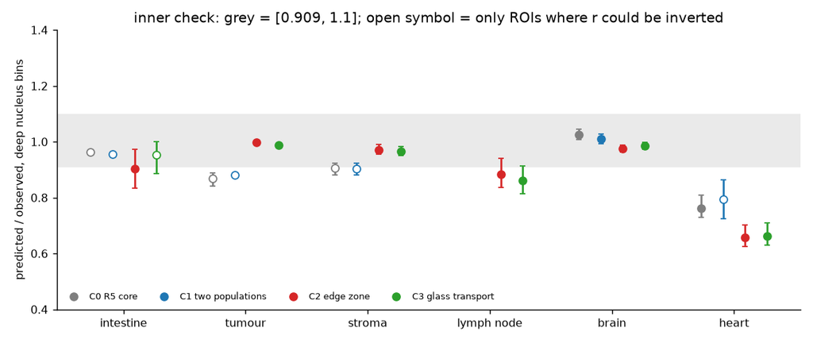

# Lumi interni (controprova CP-1)

Lumi interni dopo PH-6: UMI osservati/previsti per fascia di distanza dal bordo del lume (bootstrap per tessere, come R5)

| sezione | regola | fascia | lumi | tessere | osservati/previsti | lo | hi | esito | giudicata in CP-1 |
| --- | --- | --- | --- | --- | --- | --- | --- | --- | --- |
| intestino di topo | C0 | 2-4 | 138 | 104 | 1.060 | 1.018 | 1.098 | confermata | False |
| intestino di topo | C0 | 4-8 | 138 | 104 | 1.111 | 1.053 | 1.165 | confermata | False |
| intestino di topo | C0 | 8-16 | 138 | 104 | 1.266 | 1.172 | 1.354 | indeterminata | False |
| intestino di topo | C0 | 16-32 | 138 | 104 | 1.294 | 1.191 | 1.382 | indeterminata | False |
| intestino di topo | C2 | 2-4 | 138 | 104 | 1.078 | 1.036 | 1.114 | confermata | True |
| intestino di topo | C2 | 4-8 | 138 | 104 | 1.019 | 0.968 | 1.067 | confermata | True |
| intestino di topo | C2 | 8-16 | 138 | 104 | 1.101 | 1.019 | 1.177 | confermata | False |
| intestino di topo | C2 | 16-32 | 138 | 104 | 1.251 | 1.154 | 1.333 | indeterminata | False |
| tumore del colon (e stroma) | C0 | 2-4 | 50 | 43 | 0.790 | 0.718 | 0.851 | indeterminata | False |
| tumore del colon (e stroma) | C0 | 4-8 | 50 | 43 | 1.111 | 1.008 | 1.220 | confermata | False |
| tumore del colon (e stroma) | C0 | 8-16 | 50 | 43 | 1.516 | 1.336 | 1.739 | smentita | False |
| tumore del colon (e stroma) | C0 | 16-32 | 50 | 43 | 1.458 | 1.217 | 1.766 | indeterminata | False |
| tumore del colon (e stroma) | C2 | 2-4 | 50 | 43 | 0.815 | 0.741 | 0.880 | indeterminata | True |
| tumore del colon (e stroma) | C2 | 4-8 | 50 | 43 | 0.887 | 0.801 | 0.984 | confermata | True |
| tumore del colon (e stroma) | C2 | 8-16 | 50 | 43 | 1.404 | 1.226 | 1.620 | indeterminata | False |
| tumore del colon (e stroma) | C2 | 16-32 | 50 | 43 | 1.465 | 1.202 | 1.803 | indeterminata | False |
| linfonodo | C0 | 2-4 | 446 | 130 | 1.075 | 1.018 | 1.128 | confermata | False |
| linfonodo | C0 | 4-8 | 446 | 130 | 1.195 | 1.122 | 1.266 | indeterminata | False |
| linfonodo | C0 | 8-16 | 446 | 130 | 1.220 | 1.140 | 1.307 | indeterminata | False |
| linfonodo | C0 | 16-32 | 446 | 130 | 1.127 | 1.017 | 1.239 | confermata | False |
| linfonodo | C2 | 2-4 | 446 | 130 | 1.017 | 0.964 | 1.066 | confermata | True |
| linfonodo | C2 | 4-8 | 446 | 130 | 1.073 | 1.010 | 1.139 | confermata | True |
| linfonodo | C2 | 8-16 | 446 | 130 | 1.220 | 1.139 | 1.309 | indeterminata | False |
| linfonodo | C2 | 16-32 | 446 | 130 | 1.160 | 1.047 | 1.276 | indeterminata | False |
| cervello di topo | C0 | 2-4 | 2 | 2 | 0.854 | 0.697 | 0.910 | indeterminata | False |
| cervello di topo | C0 | 4-8 | 2 | 2 | 0.809 | 0.590 | 0.882 | indeterminata | False |
| cervello di topo | C0 | 8-16 | 2 | 2 | 0.624 | 0.473 | 0.677 | smentita | False |
| cervello di topo | C0 | 16-32 | 2 | 2 | 0.512 | 0.400 | 0.585 | smentita | False |
| cervello di topo | C2 | 2-4 | 2 | 2 | 0.897 | 0.739 | 0.952 | indeterminata | False |
| cervello di topo | C2 | 4-8 | 2 | 2 | 0.707 | 0.531 | 0.763 | smentita | False |
| cervello di topo | C2 | 8-16 | 2 | 2 | 0.665 | 0.529 | 0.709 | smentita | False |
| cervello di topo | C2 | 16-32 | 2 | 2 | 0.575 | 0.463 | 0.643 | smentita | False |
| cuore | C0 | 2-4 | 53 | 48 | 1.079 | 0.970 | 1.201 | confermata | False |
| cuore | C0 | 4-8 | 53 | 48 | 0.869 | 0.762 | 0.976 | indeterminata | False |
| cuore | C0 | 8-16 | 53 | 48 | 0.713 | 0.581 | 0.854 | indeterminata | False |
| cuore | C0 | 16-32 | 53 | 48 | 0.645 | 0.438 | 0.928 | indeterminata | False |
| cuore | C2 | 2-4 | 53 | 48 | 1.059 | 0.946 | 1.173 | confermata | True |
| cuore | C2 | 4-8 | 53 | 48 | 0.859 | 0.750 | 0.957 | indeterminata | True |
| cuore | C2 | 8-16 | 53 | 48 | 0.738 | 0.594 | 0.875 | indeterminata | False |
| cuore | C2 | 16-32 | 53 | 48 | 0.493 | 0.326 | 0.746 | smentita | False |

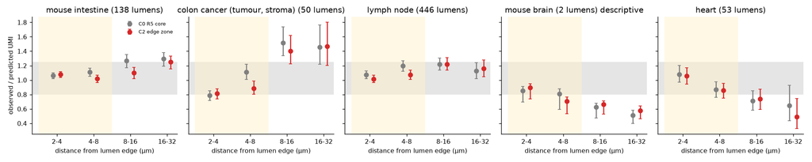

# Variabilità dentro il nucleo (M3, P-4, regola R-C) e analisi post hoc

Prototipo pre-registrato: indice di dispersione dei bin profondi dei nuclei per ROI

| ROI | r | ψ osservato | ψ simulato | rapporto | UMI per bin profondo | v | nuclei |
| --- | --- | --- | --- | --- | --- | --- | --- |
| A1_r1 | 0.507 | 5.086 | 1.785 | 2.849 | 35.819 | 0.092 | 278 |
| A1_r2 | 0.580 | 6.062 | 1.711 | 3.543 | 41.048 | 0.106 | 251 |
| A1_r3 | 0.787 | 6.485 | 1.357 | 4.778 | 44.548 | 0.115 | 356 |
| A1_r4 | 0.746 | 6.115 | 1.374 | 4.450 | 46.831 | 0.101 | 363 |
| A1_r5 | 0.783 | 5.052 | 1.306 | 3.869 | 38.549 | 0.097 | 380 |
| A2_r1 | 0.675 | 8.040 | 1.079 | 7.450 | 49.423 | 0.141 | 3041 |
| A2_r2 | 0.768 | 8.435 | 1.059 | 7.962 | 58.027 | 0.127 | 3156 |
| A2_r3 | 0.775 | 7.828 | 1.050 | 7.456 | 49.873 | 0.136 | 2835 |
| A2_r4 | 0.711 | 7.583 | 1.062 | 7.142 | 41.438 | 0.157 | 4509 |
| A2_r5 | 0.756 | 7.399 | 1.049 | 7.050 | 39.956 | 0.159 | 3743 |
| A3_r1 | 0.788 | 6.011 | 1.022 | 5.882 | 26.971 | 0.185 | 2205 |
| A3_r2 | 0.917 | 4.321 | 1.021 | 4.233 | 19.490 | 0.169 | 1226 |
| A3_r3 | 0.821 | 5.800 | 1.024 | 5.665 | 29.957 | 0.159 | 2189 |
| A3_r4 | 0.858 | 6.224 | 1.016 | 6.129 | 29.212 | 0.178 | 2292 |
| A3_r5 | 0.719 | 5.985 | 1.050 | 5.701 | 31.435 | 0.157 | 2806 |
| A4_f1 | 0.508 | 3.463 | 1.109 | 3.122 | 14.556 | 0.162 | 3124 |
| A4_f2 | 0.513 | 3.515 | 1.123 | 3.129 | 15.092 | 0.158 | 2676 |
| A4_p1 | 0.546 | 2.515 | 1.066 | 2.358 | 9.555 | 0.152 | 2411 |
| A4_p2 | 0.566 | 3.204 | 1.085 | 2.953 | 13.669 | 0.155 | 2803 |
| A4_p3 | 0.560 | 3.323 | 1.082 | 3.072 | 13.240 | 0.169 | 1960 |
| A5_r1 | 1.519 | 10.153 | 1.042 | 9.748 | 81.764 | 0.111 | 933 |
| A5_r2 | 1.449 | 11.709 | 1.044 | 11.215 | 90.395 | 0.118 | 683 |
| A5_r3 | 1.483 | 11.856 | 1.037 | 11.434 | 94.325 | 0.115 | 559 |
| A5_r4 | 1.403 | 11.880 | 1.044 | 11.375 | 92.679 | 0.117 | 434 |
| A5_r5 | 1.508 | 11.274 | 1.056 | 10.680 | 91.529 | 0.112 | 791 |
| A6_r1 | 2.029 | 2.887 | 1.046 | 2.761 | 11.493 | 0.160 | 359 |
| A6_r2 | 2.883 | 2.651 | 1.032 | 2.569 | 8.136 | 0.199 | 274 |
| A6_r3 | 2.672 | 2.681 | 1.007 | 2.662 | 8.475 | 0.198 | 195 |
| A6_r4 | 2.605 | 3.971 | 1.011 | 3.926 | 11.681 | 0.253 | 219 |
| A6_r5 | 2.027 | 3.485 | 1.058 | 3.296 | 12.467 | 0.195 | 350 |

Post hoc PH-2 (con i fattori di riga e colonna) e PH-3 (correlazione in più fra bin dello stesso nucleo a 2 e 4 µm), per tessuto

| archetype | n_roi | ratio_pre | ratio_pre_lo | ratio_pre_hi | v_pre | v_pre_lo | v_pre_hi | ratio | ratio_lo | ratio_hi | v | v_lo | v_hi | exc_lag1 | exc_lag1_lo | exc_lag1_hi | exc_lag2 | exc_lag2_lo | exc_lag2_hi |
| --- | --- | --- | --- | --- | --- | --- | --- | --- | --- | --- | --- | --- | --- | --- | --- | --- | --- | --- | --- |
| A1 | 5 | 3.898 | 3.266 | 4.516 | 0.102 | 0.096 | 0.110 | 2.329 | 1.977 | 2.681 | 0.044 | 0.037 | 0.051 | 0.092 | 0.052 | 0.130 | -0.020 | -0.071 | 0.033 |
| A2 | 5 | 7.412 | 7.148 | 7.695 | 0.144 | 0.133 | 0.155 | 4.070 | 4.002 | 4.141 | 0.069 | 0.061 | 0.078 | 0.247 | 0.235 | 0.257 | -0.006 | -0.013 | -0.001 |
| A3 | 5 | 5.522 | 4.856 | 5.958 | 0.170 | 0.160 | 0.179 | 3.534 | 3.222 | 3.800 | 0.095 | 0.086 | 0.101 | 0.236 | 0.219 | 0.256 | -0.021 | -0.047 | 0.004 |
| A4 | 5 | 2.927 | 2.644 | 3.114 | 0.159 | 0.154 | 0.164 | 1.770 | 1.660 | 1.858 | 0.063 | 0.059 | 0.068 | 0.093 | 0.081 | 0.105 | -0.054 | -0.071 | -0.034 |
| A5 | 5 | 10.890 | 10.271 | 11.367 | 0.115 | 0.112 | 0.117 | 3.889 | 3.582 | 4.197 | 0.033 | 0.031 | 0.036 | 0.382 | 0.332 | 0.433 | 0.086 | 0.043 | 0.129 |
| A6 | 5 | 3.043 | 2.645 | 3.529 | 0.201 | 0.179 | 0.231 | 2.570 | 2.212 | 3.060 | 0.153 | 0.128 | 0.185 | 0.207 | 0.137 | 0.271 | -0.034 | -0.057 | -0.011 |

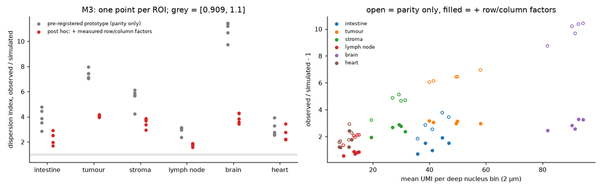

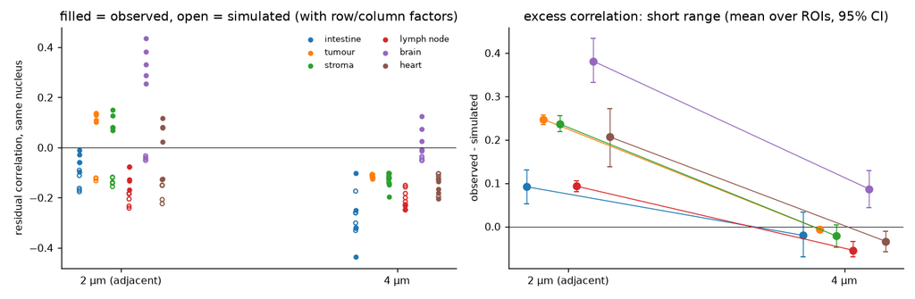

# Revisione avversariale (G-5)

Quattro revisori indipendenti, ciascuno con codice proprio e accesso in sola lettura; rapporti e codice in `/mnt/micron/geo_spatialtrans/S2.0/review/<revisore>/`.

| revisore | che cosa | controlli superati | non superati |
| --- | --- | --- | --- |
| documento | (e) documento contro dati e decisioni: ogni numero, fonte e decisione | 161/189 | T9-vRC-A1, T9-vRC-A2, T9-vRC-A3, T9-vRC-A4, T9-vRC-A5, T9-vRC-A6, T9-sin-src, T5-half … |
| nucleo | (c) controllo interno in 3 ROI (tumore, cervello), (d) ψ osservato e simulato, PH-2, PH-3 in 7 ROI | 203/203 |  |
| strisce | (a) M1 dai dati grezzi in intestino, linfonodo, cervello; 5 prove di falsificazione | 164/174 | SENT-A4-rows, SENT-A4-cols, SENT-A5-rows, ITER-A1-rows-sd_repro, ITER-A1-rows-lag1_repro, ITER-A1-cols-lag1_repro, ITER-A4-rows-sd_repro, ITER-A4-rows-lag1_repro … |
| bordi | (b) quattro regole rivalutate su 40 finestre, ottimizzazione propria su 20, R-A da tutte le 314 | 428/435 | N-C3-vs-PH5, b2-A23-t2100_1500-C2, wp-A23-t2700_2400-C0, wp-A23-t2100_1500-C2, wp-A1-t900_150-C2, wp-A1-t3000_3000-C2, wp-A1-t2700_3150-C2 |

Dubbi del revisore del documento: 38. Come sono stati chiusi è scritto qui sotto e nel file dello step.

- **Strisce**: righe e colonne con tessuto e zero UMI davano un fattore sentinella che falsava la parità (linfonodo, cervello); la parte lenta dei fattori deriva con le iterazioni. Chiusi con PH-5: righe a zero UMI tolte, per il simulatore la sola parte fine (stabile), passo 1 calibrato su sezioni sintetiche. Gli esiti di P-1 e P-2 non cambiano.
- **Bordi**: soluzioni ferme con la coda spenta (fino a 32 unità di log-verosimiglianza nel campione del revisore). Chiuso con PH-6: 107 coppie finestra × regola riadattate, nessun esito pre-registrato cambia, cambiano lunghezza e massa della coda; i valori del design sono quelli corretti. La tolleranza di 1e-6 sulla log-verosimiglianza era irraggiungibile (modello in precisione singola): giudicata a 0.05, come in R5.
- **Nucleo**: 203/203; l’eccesso di variabilità c’è anche nella corona e nello spazio acellulare (provvisorio): il campo del simulatore copre tutto il tessuto (DEC-040). Nell’intestino v è sottostimato di circa il 20 % (bin profondi sulla maschera non spostata): BACKLOG.
- **Documento**: i numeri sbagliati e le frasi oltre i dati sono corretti nel design v0.2; le voci che restano aperte sono nei limiti (sezione 17) e nel BACKLOG.

# Cosa è girato

Server lesexp, `.venv` del progetto, un thread per processo. Primo calcolo `/mnt/micron/geo_spatialtrans/S2.0/run1` (catena `tools/S2.0_chain.sh`), seconda esecuzione completa per G-4 in `run2` (stesso seme), soluzioni dei bordi corrette e catena a valle in `run1_wfix` (PH-6). Seme 20261103, B = 2000. Processi da 16 a 40 secondo temperatura e richieste di Luca (protezione termica `tools/S2.0_thermal_guard.sh`); due arresti chiesti da Luca e ripresi dai file salvati. Durate: batteria G-1 1 343 s; una finestra di bordo circa 41 minuti di un processore per le quattro regole (mediana); 314 finestre per esecuzione.

| cancello | esito |
| --- | --- |
| G-1 batteria (`tools/S2.0_test.py`) | vedi `results/S2.0/S2.0_G1.txt` |
| G-2 md5 dei file letti | `results/S2.0/S2.0_md5_before.txt`, `S2.0_md5_after.txt`, esito in `S2.0_G2.txt` |
| G-3 documento contro dati (`tools/S2.0_design_check.py`) | `results/S2.0/S2.0_G3_full.txt` |
| G-4 riproducibilità (`tools/S2.0_repro.sh`) | `results/S2.0/S2.0_G4_full.txt` |

Commit principali sul ramo `step2-visium-grid`: afef06b (cancelli), a8690b3 (ok di Luca), f2a23d7 e 86410af (correzioni AM-1…AM-5), 315fa83 (codice di G-1), c8a1f5b (ripresa della seconda esecuzione), db96bcb (PH-6); l’ultimo commit è quello di questo report.

# Appendice

## Da dove vengono i numeri del riassunto

| frase del riassunto | fonte (tabella o file, riga) | valore letto |
| --- | --- | --- |
| zona di bordo: entro 7-25 µm dal bordo, allargamento di 4.5-6.2 µm | results/S2.0/wfix/S2.0_edges_sections.csv, C2, D e sigma_e, sezioni giudicate | D 6.86-24.75 µm; σ_e 4.49-6.23 µm |
| vince in tutte e quattro le sezioni giudicate | results/S2.0/wfix/S2.0_RA.json (somma degli AIC, soluzioni corrette) | {“A1”: “C2”, “A23”: “C2”, “A4”: “C2”, “A5”: “C2”} |
| bordi dei buchi interni: nessuna delle 8 fuori (6 dentro, 2 incerte) | results/S2.0/wfix/S2.0_CP1_lumens.csv, C2, celle giudicate | confermata: 6, indeterminata: 2 |
| nucleo/citoplasma riprodotto in tumore, stroma, cervello; incerto in intestino e linfonodo; non nel cuore | results/S2.0/wfix/S2.0_inner_summary.csv, C2 | A1 0.903 indeterminata; A2 0.999 confermata; A3 0.972 confermata; A4 0.884 indeterminata; A5 0.976 confermata; A6 0.658 smentita |
| coda fino a 41.5 µm nel linfonodo | results/S2.0/wfix/S2.0_edges_sections.csv, C2, ell | A4 41.50 µm |
| il difetto c’era già in R5 in una finestra del tumore | run1/edges_wfix/A23_t2700_1800.json, C0 (nucleo di R5) | miglioramento 166.83 unità |
| alternanza fino a 1.75 volte fra colonne dispari e pari nell’intestino | results/S2.0/S2.0_PH5_sections.csv, A1 cols | 1.750 |
| ogni riga e colonna cattura circa il 20 % in più o in meno | results/S2.0/S2.0_PH5_sections.csv, sd_repro_hp (log) | 0.180-0.251 |
| alternanza del linfonodo da 0.98 a 1.00 | run1/stripes/A4.json (rows) e S2.0_PH5_sections.csv (A4 rows) | 0.9797 → 0.9964 |
| variabilità da 3 a 11 volte quella simulata | results/S2.0/S2.0_PH23_disp.csv, ratio_pre | 2.93-10.89 |
| da un quarto (cuore) a sette decimi (cervello) dalle strisce, circa metà negli altri | results/S2.0/S2.0_PH23_disp.csv, 1 − (ratio − 1)/(ratio_pre − 1) | A1 0.54; A2 0.52; A3 0.44; A4 0.60; A5 0.71; A6 0.23 |
| quadratini vicini si somigliano, a 4 µm molto meno | results/S2.0/S2.0_PH23_disp.csv, exc_lag1 / exc_lag2 | 2 µm 0.09-0.38; 4 µm -0.05-0.09 |
| scarti fino a 2 centesimi di unità (precisione singola) | /mnt/micron/geo_spatialtrans/S2.0/review/bordi/S2.0_G5_bordi_checks.csv, righe b1--*, abs_diff massimo | 0.0191 |
| la somma sulle finestre di una sezione separa le regole di oltre cento unità | results/S2.0/wfix/S2.0_edges_tiles.csv: differenza minima fra le somme degli AIC della prima e della seconda regola, divisa per 2 (unità di log-verosimiglianza) | 114.5 (A4) |
| il revisore del documento ha trovato 38 punti | /mnt/micron/geo_spatialtrans/S2.0/review/documento/S2.0_G5_documento.md, voci D- | 38 |
| revisore documento | /mnt/micron/geo_spatialtrans/S2.0/review/documento/S2.0_G5_documento_checks.csv, colonna pass | 161/189 |
| revisore nucleo | /mnt/micron/geo_spatialtrans/S2.0/review/nucleo/S2.0_G5_nucleo_comparisons.csv, colonna pass | 203/203 |
| revisore strisce | /mnt/micron/geo_spatialtrans/S2.0/review/strisce/S2.0_G5_strisce_comparisons.csv, colonna pass | 164/174 |
| revisore bordi | /mnt/micron/geo_spatialtrans/S2.0/review/bordi/S2.0_G5_bordi_checks.csv, colonna pass | 428/435 |
| cancello G1 | results/S2.0/S2.0_G1.txt, ultima riga | S2.0_test: 44/44 PASS (1343 s) |
| cancello G2 | results/S2.0/S2.0_G2.txt, ultima riga | G-2 PASS: 1623/1623 file letti con md5 identici prima e dopo (results/S2.0/S2.0_md5_before.txt, _after.txt) |
| cancello G3 | results/S2.0/S2.0_G3.txt, ultima riga | S2.0_design_check: 37/37 PASS |
| cancello G4 | results/S2.0/S2.0_G4.txt, ultima riga | G-4 PASS: 10/10 tabelle con md5 identici, 514 file per unità identici a meno dei tempi (run1 contro run2) |